# Peekbank Effect Size Demo

Martin Zettersten & the Peekbank Team

09 May, 2023

# Download peekbankr

If you haven’t downloaded peekbankr (https://github.com/langcog/peekbankr) yet, be sure to do so first by uncommenting the lines below.

```r
knitr::opts_chunk$set(cache = FALSE, arn = FALSE,warning=FALSE, message = FALSE,cache.lazy = FALSE)

# install.packages("remotes") # can also use devtools
# remotes::install_github("langcog/peekbankr")
```

# Preliminaries and data loading

Load packages. Since it takes a while to download and join the data, you probably want to just do that once, and then save the resulting dataset. Setting the parameter FIRST_TIME to FALSE after you run the script the first time allows you to bypass the data download process on subsequent runs. You can also use the most recent data file uploaded to GitHub.

```r
FIRST_TIME = FALSE # set to true first time to download data from DB

library(peekbankr)
library(tidyverse)
library(here)
library(lme4)
library(lmerTest)
library(effectsize)
library(metafor)
#library(cowplot)
#theme_set(theme_cowplot())
```

The next steps demonstrate how to

1. Connect to the peekbank database
2. Pull individual tables using peekbankr functions (“get_[name_of_table]”). For details on the specific tables, including a codebook, see the peekbank documentation: https://peekbank.stanford.edu/docs/documentation/
3. Join these tables together to get a single tidy dataset in “long” format (each row is an observation at a particular timepoint)

```r
#get all of the tables you need
datasets <- get_datasets()
administrations <- get_administrations()
subjects <- get_subjects()
aoi_timepoints <- get_aoi_timepoints()
stimuli <- get_stimuli()
trial_types <- get_trial_types()
trials <- get_trials()

aoi_data_joined <- aoi_timepoints %>%
  right_join(administrations) %>%
  right_join(subjects) %>%
  right_join(trials) %>%
  right_join(trial_types) %>%
  right_join(datasets) %>%
  mutate(stimulus_id = target_id) %>% #just joining in the target properties. Add a second join here if the distractor info is needed too
  right_join(stimuli)

save(file = here("peekbank_effsize","data","aoi_data_joined.Rds"), aoi_data_joined)
```

# Load cached data

```r
load(file = here("peekbank_effsize","data","aoi_data_joined.Rds"))
```

# Average trial-level data

Goal here is to average looking performance for each trial across a critical window (t_min and t_max). We also set a threshold for how much looking data must be included in order for the trial to merit inclusion.

```r
#### PARAMETERS TO SET ####
#critical window dimensions roughly consistent with e.g., Swingley & Aslin, 2002
t_min <- 300
t_max <- 2000
#proportion missing trials threshold (any trial in which over half of the critical window missing is looking data is excluded )
max_prop_missing <- 0.5
#min/max age (in mos)
min_age <- 9
max_age <- 27
#age bin size (number of months per bin)
age_bin_size <- 6


by_trial_means <- aoi_data_joined %>%
  #restrict to english datasets (this is just because there are so few non-English datasets atm)
  filter(native_language == "eng") %>%
  #restrict age range
  filter(age > min_age, age <= max_age) %>%
  # familiar target items only %>%
  filter(stimulus_novelty == "familiar") %>%
  #window of analysis
  filter(t_norm >= t_min, t_norm <= t_max) %>%
  #bin ages (can adjust size of age bins here)
  mutate(age_binned = cut(age, seq(min_age,max_age,age_bin_size))) %>%
  group_by(dataset_name,subject_id, trial_id, english_stimulus_label,
           age, age_binned) %>%
  summarise(prop_target_looking = sum(aoi == "target", na.rm = TRUE) /
              (sum(aoi == "target", na.rm=TRUE) +
                 sum(aoi=="distractor", na.rm=TRUE)),
            prop_missing = mean(aoi %in% c("missing","other"), na.rm = TRUE)) %>%
  #remove trials with insufficient looking to target or distractor
  filter(prop_missing<=max_prop_missing)
```

# Average within subjects, by-dataset

One could consider excluding participants based on the number of trials a participant contributes overall here.

```r
by_subj_means <- by_trial_means %>%
  group_by(dataset_name,subject_id,age_binned) %>%
  summarise(
    trial_num=n(),
    avg_target_looking =mean(prop_target_looking,na.rm=TRUE)
  )
```

# Average across subjects - by dataset and age bin, by dataset, and by age bin

```r
#make this a function so we can use map
compute_cohens_d <- function(current_data) {
  temp <- cohens_d(avg_target_looking-0.5~1,data=current_data)
  temp
}

by_dataset_age_means <- by_subj_means %>%
  group_by(dataset_name, age_binned) %>%
  mutate(subj_n=n()) %>%
  group_by(dataset_name, age_binned,subj_n) %>%
  #filter to at least 5 subjects
  filter(subj_n>=5) %>%
  mutate(
    mean_target = mean(avg_target_looking),
    sd_target=sd(avg_target_looking),
    d_target = (mean_target-0.5)/sd_target
  ) %>%
  group_by(dataset_name, age_binned,subj_n,mean_target,sd_target,d_target) %>%
  nest() %>%
  mutate(cohens_d = purrr::map(data,compute_cohens_d)) %>%
  select(-data) %>%
  unnest(cols=c(cohens_d)) %>%
  ungroup() %>%
  mutate(
    chance=0.5
  )

by_dataset_means <- by_subj_means %>%
  group_by(dataset_name) %>%
  mutate(
    subj_n=n()
  ) %>%
  #filter to at least 5 subjects
  filter(subj_n>=5) %>%
  mutate(
    mean_target = mean(avg_target_looking),
    sd_target=sd(avg_target_looking),
    d_target = (mean_target-0.5)/sd_target
  ) %>%
  group_by(dataset_name,subj_n,mean_target,sd_target,d_target) %>%
  nest() %>%
  mutate(
    cohens_d = purrr::map(data,compute_cohens_d)) %>%
  select(-data) %>%
  unnest(cols=c(cohens_d))

by_age_means <- by_subj_means %>%
  group_by(age_binned) %>%
  mutate(
    subj_n=n()
  ) %>%
  #filter to at least 5 subjects
  filter(subj_n>=5) %>%
  mutate(
    mean_target = mean(avg_target_looking),
    sd_target=sd(avg_target_looking),
    d_target = (mean_target-0.5)/sd_target
  ) %>%
  group_by(age_binned,subj_n,mean_target,sd_target,d_target) %>%
  nest() %>%
  mutate(
    cohens_d = purrr::map(data,compute_cohens_d)) %>%
  select(-data) %>%
  unnest(cols=c(cohens_d))
```

# Plot Effect Sizes

Plotting effect sizes by dataset within each age bracket

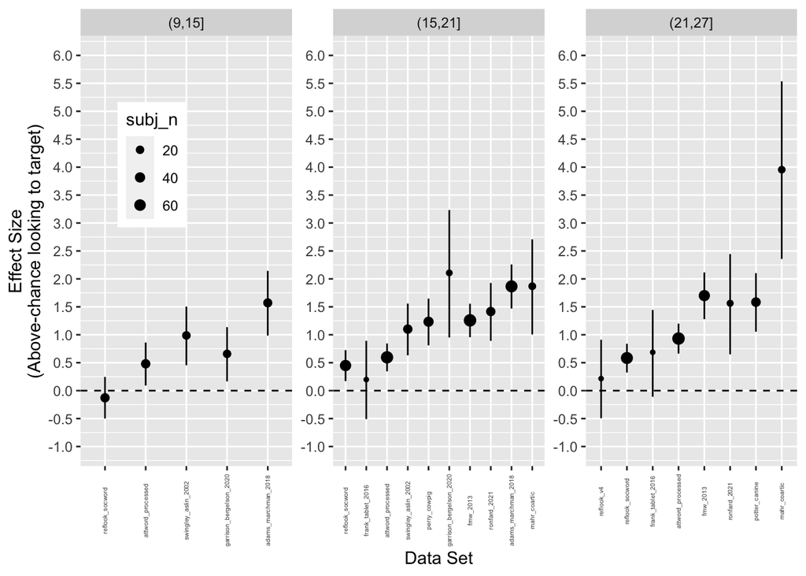

```r
ggplot(by_dataset_age_means,aes(reorder(dataset_name,Cohens_d,mean),Cohens_d))+
  geom_hline(yintercept=0,linetype="dashed")+
  geom_point(aes(size=subj_n))+
  geom_errorbar(aes(ymin=CI_low,ymax=CI_high),width=0)+
  scale_size(range = c(1, 3))+
  #geom_point()+
  theme(axis.text.x=element_text(angle=90,size=4,vjust=0.5))+
  #theme(legend.position="none")+
  xlab("Data Set")+
  ylab("Effect Size\n(Above-chance looking to target)")+
  facet_wrap(~age_binned,nrow=1,scales = "free")+
  theme(legend.position=c(0.1,0.7))+
  scale_y_continuous(breaks=seq(-1,6,0.5),limits=c(-1,6))
```

# Meta-analysis of specific age group

## 9-15-month olds

```r
#using the metafor package
#this is a little hacky, in order to get the effect size for a one-sample test against chance
effect_sizes_9_15 <- escalc(measure="SMD",m1i=mean_target,m2i=chance,sd1i=sd_target,sd2i=sd_target,n1i=subj_n,n2i=subj_n,data=filter(by_dataset_age_means,age_binned=="(9,15]"),slab=dataset_name)
meta_model <- rma(yi,vi,data=effect_sizes_9_15)
meta_model
```

```
##
## Random-Effects Model (k = 5; tau^2 estimator: REML)
##
## tau^2 (estimated amount of total heterogeneity): 0.2998 (SE = 0.2757)
## tau (square root of estimated tau^2 value):      0.5475
## I^2 (total heterogeneity / total variability):   77.20%
## H^2 (total variability / sampling variability):  4.39
##
## Test for Heterogeneity:
## Q(df = 4) = 17.8439, p-val = 0.0013
##
## Model Results:
##
## estimate      se    zval    pval   ci.lb   ci.ub
##   0.6853  0.2793  2.4541  0.0141  0.1380  1.2327  *
##
## ---
## Signif. codes:  0 '***' 0.001 '**' 0.01 '*' 0.05 '.' 0.1 ' ' 1
```

Forest Plot

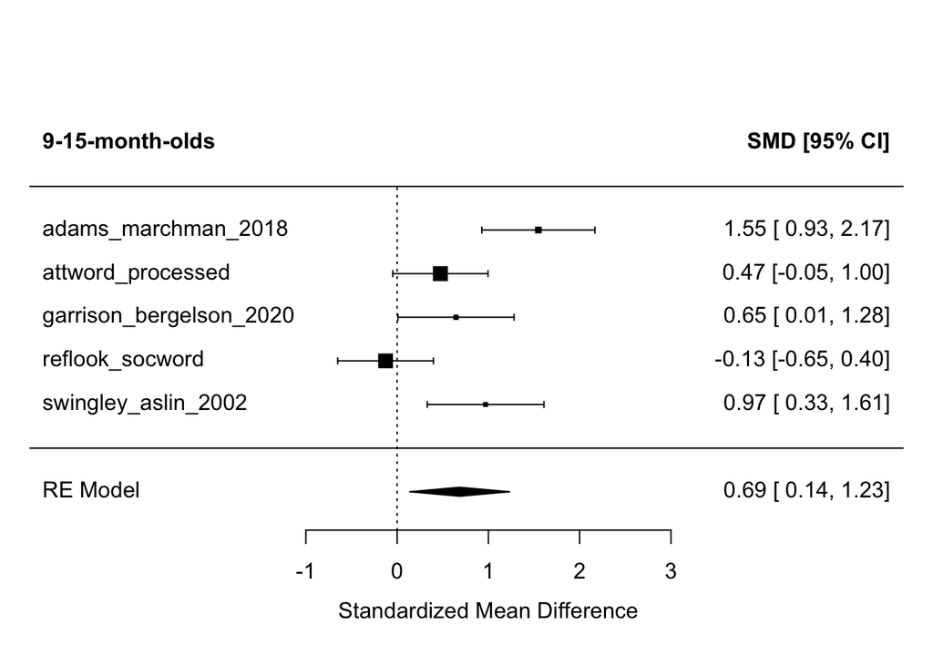

```r
forest(meta_model,header="9-15-month-olds")
```

## 15-21-month olds

```r
#using the metafor package
#this is a little hacky, in order to get the effect size for a one-sample test against chance
effect_sizes_15_21 <- escalc(measure="SMD",m1i=mean_target,m2i=chance,sd1i=sd_target,sd2i=sd_target,n1i=subj_n,n2i=subj_n,data=filter(by_dataset_age_means,age_binned=="(15,21]"),slab=dataset_name)
meta_model <- rma(yi,vi,data=effect_sizes_15_21)
meta_model
```

```
##
## Random-Effects Model (k = 10; tau^2 estimator: REML)
##
## tau^2 (estimated amount of total heterogeneity): 0.2346 (SE = 0.1502)
## tau (square root of estimated tau^2 value):      0.4843
## I^2 (total heterogeneity / total variability):   79.27%
## H^2 (total variability / sampling variability):  4.82
##
## Test for Heterogeneity:
## Q(df = 9) = 44.7901, p-val < .0001
##
## Model Results:
##
## estimate      se    zval    pval   ci.lb   ci.ub
##   1.1582  0.1801  6.4319  <.0001  0.8053  1.5112  ***
##
## ---
## Signif. codes:  0 '***' 0.001 '**' 0.01 '*' 0.05 '.' 0.1 ' ' 1
```

Forest Plot

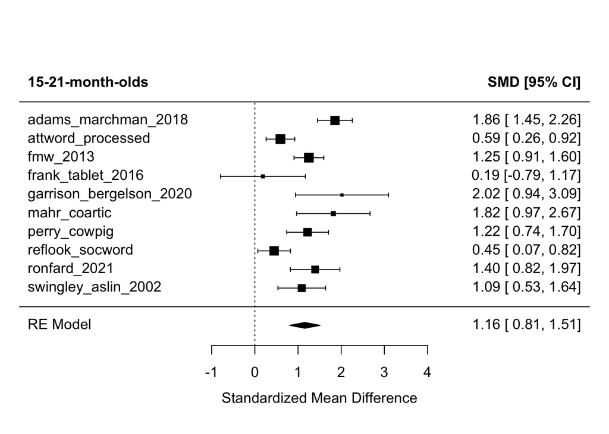

```r
forest(meta_model,header="15-21-month-olds")
```

## 21-27-month olds

```r
#using the metafor package
#this is a little hacky, in order to get the effect size for a one-sample test against chance
effect_sizes_21_27 <- escalc(measure="SMD",m1i=mean_target,m2i=chance,sd1i=sd_target,sd2i=sd_target,n1i=subj_n,n2i=subj_n,data=filter(by_dataset_age_means,age_binned=="(21,27]"),slab=dataset_name)
meta_model <- rma(yi,vi,data=effect_sizes_21_27)
meta_model
```

```
##
## Random-Effects Model (k = 8; tau^2 estimator: REML)
##
## tau^2 (estimated amount of total heterogeneity): 0.7738 (SE = 0.4917)
## tau (square root of estimated tau^2 value):      0.8796
## I^2 (total heterogeneity / total variability):   90.76%
## H^2 (total variability / sampling variability):  10.82
##
## Test for Heterogeneity:
## Q(df = 7) = 42.4727, p-val < .0001
##
## Model Results:
##
## estimate      se    zval    pval   ci.lb   ci.ub
##   1.3094  0.3400  3.8516  0.0001  0.6431  1.9757  ***
##
## ---
## Signif. codes:  0 '***' 0.001 '**' 0.01 '*' 0.05 '.' 0.1 ' ' 1
```

Forest Plot

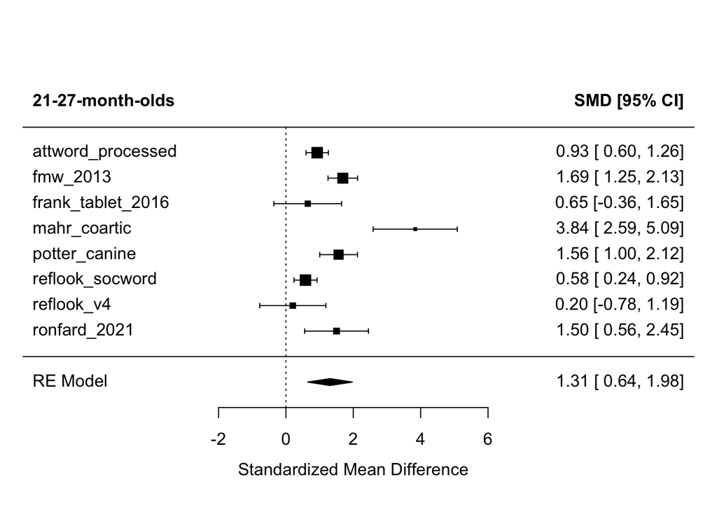

```r
forest(meta_model,header="21-27-month-olds")
```